# Given the distances from an interior point to three vertices of a rectangle, find the maximum and minimum possible areas of the rectangle.

author: A.Casares M. date: January 6th, 2017 autosize: true transition: rotate

# The original problem and the actual data:

left: 45%

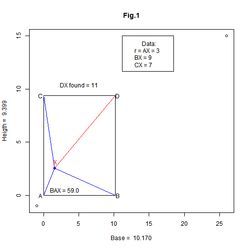

**Given AX, BX and CX, is the 4th distance DX determined?**

- Answer: Yes, with Pythagoras’ help.  
  For instance:  
  Let it be BX = 9, CX = 7, AX = 3.  
  Then DX^2 = 81 + 49 - 9 =>  
  DX = 11.

# The general question:

left: 50% transition: zoom

The point X moves along a circle with r=AX and center A.

When X moves, the rectangle adjusts its dimensions.

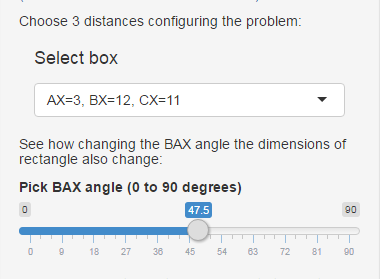

alt text

**To see it and examine the problem’s behaviour:**  
- You can choose the three data distances in a select box. - And vary the polar angle BAX through a slider gadget. - The figures react to these changes. You can see how the area keeps changing.  
**Between what limits?**

# Curve of areas as function of polar angle.

left: 45% transition: fade

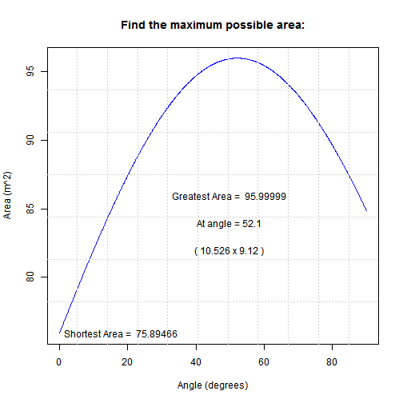

***  
**Empirical procedure:**

- Areas computed in each point of an uniform sample.
- The extreme areas may be easily computed from it.
- The figure shows the answers for a set of distances
- The minimum value of the area is at angle BAX = 0 degrees.

**Finding the analytical function and its derivative is hard to do.**

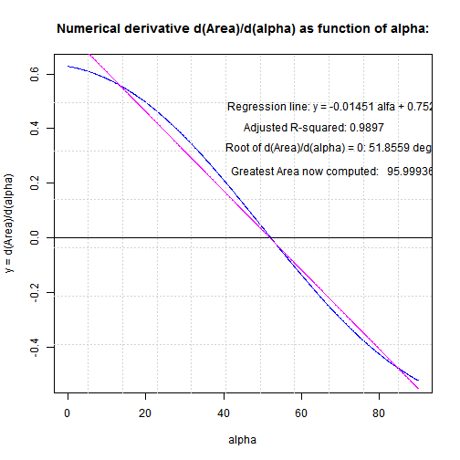

*** - Looks for angles making the derivative null, without using the cumbersome function.

- Numerical derivatives, shown in blue, exhibit good linear pattern.
- Fits a linear model with high R-square.
- Answers are practically indistinguishable, and close to former ones.